# Optimal Treatment Analysis

## Outcome Variable

**Outcome Variable:** whz

## Predictor Variables

**Intervention Variable:** hdlvry

**Adjustment Set:**

- arm
- sex
- W_mage
- meducyrs
- feducyrs
- hhwealth_quart
- single
- W_nrooms
- brthmon
- W_parity
- impsan
- delta_W_mage
- delta_meducyrs
- delta_feducyrs
- delta_hhwealth_quart
- delta_single
- delta_W_nrooms
- delta_brthmon
- delta_W_parity
- delta_impsan

## Stratifying Variables

The analysis was stratified on these variable(s):

- agecat
- studyid
- country

## Data Summary

| agecat | studyid | country | hdlvry | n_cell | n |
| --- | --- | --- | --- | --- | --- |
| Birth | CMC-V-BCS-2002 | INDIA | 0 | 86 | 86 |
| Birth | CMC-V-BCS-2002 | INDIA | 1 | 0 | 86 |
| Birth | COHORTS | INDIA | 0 | 2763 | 4389 |
| Birth | COHORTS | INDIA | 1 | 1626 | 4389 |
| Birth | EE | PAKISTAN | 0 | 120 | 175 |
| Birth | EE | PAKISTAN | 1 | 55 | 175 |
| Birth | GMS-Nepal | NEPAL | 0 | 143 | 596 |
| Birth | GMS-Nepal | NEPAL | 1 | 453 | 596 |
| Birth | IRC | INDIA | 0 | 337 | 343 |
| Birth | IRC | INDIA | 1 | 6 | 343 |
| Birth | JiVitA-3 | BANGLADESH | 0 | 27 | 292 |
| Birth | JiVitA-3 | BANGLADESH | 1 | 265 | 292 |
| Birth | JiVitA-4 | BANGLADESH | 0 | 500 | 2384 |
| Birth | JiVitA-4 | BANGLADESH | 1 | 1884 | 2384 |
| Birth | NIH-Crypto | BANGLADESH | 0 | 548 | 707 |
| Birth | NIH-Crypto | BANGLADESH | 1 | 159 | 707 |
| Birth | PROVIDE | BANGLADESH | 0 | 387 | 532 |
| Birth | PROVIDE | BANGLADESH | 1 | 145 | 532 |
| Birth | SAS-CompFeed | INDIA | 0 | 108 | 957 |
| Birth | SAS-CompFeed | INDIA | 1 | 849 | 957 |
| 6 months | CMC-V-BCS-2002 | INDIA | 0 | 357 | 365 |
| 6 months | CMC-V-BCS-2002 | INDIA | 1 | 8 | 365 |
| 6 months | COHORTS | INDIA | 0 | 2896 | 4694 |
| 6 months | COHORTS | INDIA | 1 | 1798 | 4694 |
| 6 months | EE | PAKISTAN | 0 | 252 | 373 |
| 6 months | EE | PAKISTAN | 1 | 121 | 373 |
| 6 months | GMS-Nepal | NEPAL | 0 | 129 | 528 |
| 6 months | GMS-Nepal | NEPAL | 1 | 399 | 528 |
| 6 months | IRC | INDIA | 0 | 400 | 408 |
| 6 months | IRC | INDIA | 1 | 8 | 408 |
| 6 months | JiVitA-3 | BANGLADESH | 0 | 39 | 334 |
| 6 months | JiVitA-3 | BANGLADESH | 1 | 295 | 334 |
| 6 months | JiVitA-4 | BANGLADESH | 0 | 1082 | 4042 |
| 6 months | JiVitA-4 | BANGLADESH | 1 | 2960 | 4042 |
| 6 months | NIH-Crypto | BANGLADESH | 0 | 554 | 715 |
| 6 months | NIH-Crypto | BANGLADESH | 1 | 161 | 715 |
| 6 months | PROVIDE | BANGLADESH | 0 | 450 | 603 |
| 6 months | PROVIDE | BANGLADESH | 1 | 153 | 603 |
| 6 months | SAS-CompFeed | INDIA | 0 | 147 | 1088 |
| 6 months | SAS-CompFeed | INDIA | 1 | 941 | 1088 |
| 6 months | SAS-FoodSuppl | INDIA | 0 | 76 | 380 |
| 6 months | SAS-FoodSuppl | INDIA | 1 | 304 | 380 |
| 6 months | TanzaniaChild2 | TANZANIA, UNITED REPUBLIC OF | 0 | 1888 | 1920 |
| 6 months | TanzaniaChild2 | TANZANIA, UNITED REPUBLIC OF | 1 | 32 | 1920 |
| 24 months | CMC-V-BCS-2002 | INDIA | 0 | 361 | 369 |
| 24 months | CMC-V-BCS-2002 | INDIA | 1 | 8 | 369 |
| 24 months | COHORTS | INDIA | 0 | 2214 | 3533 |
| 24 months | COHORTS | INDIA | 1 | 1319 | 3533 |
| 24 months | EE | PAKISTAN | 0 | 112 | 167 |
| 24 months | EE | PAKISTAN | 1 | 55 | 167 |
| 24 months | GMS-Nepal | NEPAL | 0 | 118 | 455 |
| 24 months | GMS-Nepal | NEPAL | 1 | 337 | 455 |
| 24 months | IRC | INDIA | 0 | 401 | 409 |
| 24 months | IRC | INDIA | 1 | 8 | 409 |
| 24 months | JiVitA-3 | BANGLADESH | 0 | 34 | 289 |
| 24 months | JiVitA-3 | BANGLADESH | 1 | 255 | 289 |
| 24 months | JiVitA-4 | BANGLADESH | 0 | 1032 | 3993 |
| 24 months | JiVitA-4 | BANGLADESH | 1 | 2961 | 3993 |
| 24 months | NIH-Crypto | BANGLADESH | 0 | 391 | 514 |
| 24 months | NIH-Crypto | BANGLADESH | 1 | 123 | 514 |
| 24 months | PROVIDE | BANGLADESH | 0 | 433 | 579 |
| 24 months | PROVIDE | BANGLADESH | 1 | 146 | 579 |
| 24 months | TanzaniaChild2 | TANZANIA, UNITED REPUBLIC OF | 0 | 6 | 6 |
| 24 months | TanzaniaChild2 | TANZANIA, UNITED REPUBLIC OF | 1 | 0 | 6 |

The following strata were considered:

- agecat: 24 months, studyid: CMC-V-BCS-2002, country: INDIA
- agecat: 24 months, studyid: COHORTS, country: INDIA
- agecat: 24 months, studyid: EE, country: PAKISTAN
- agecat: 24 months, studyid: GMS-Nepal, country: NEPAL
- agecat: 24 months, studyid: IRC, country: INDIA
- agecat: 24 months, studyid: JiVitA-3, country: BANGLADESH
- agecat: 24 months, studyid: JiVitA-4, country: BANGLADESH
- agecat: 24 months, studyid: NIH-Crypto, country: BANGLADESH
- agecat: 24 months, studyid: PROVIDE, country: BANGLADESH
- agecat: 24 months, studyid: TanzaniaChild2, country: TANZANIA, UNITED REPUBLIC OF
- agecat: 6 months, studyid: CMC-V-BCS-2002, country: INDIA
- agecat: 6 months, studyid: COHORTS, country: INDIA
- agecat: 6 months, studyid: EE, country: PAKISTAN
- agecat: 6 months, studyid: GMS-Nepal, country: NEPAL
- agecat: 6 months, studyid: IRC, country: INDIA
- agecat: 6 months, studyid: JiVitA-3, country: BANGLADESH
- agecat: 6 months, studyid: JiVitA-4, country: BANGLADESH
- agecat: 6 months, studyid: NIH-Crypto, country: BANGLADESH
- agecat: 6 months, studyid: PROVIDE, country: BANGLADESH
- agecat: 6 months, studyid: SAS-CompFeed, country: INDIA
- agecat: 6 months, studyid: SAS-FoodSuppl, country: INDIA
- agecat: 6 months, studyid: TanzaniaChild2, country: TANZANIA, UNITED REPUBLIC OF
- agecat: Birth, studyid: CMC-V-BCS-2002, country: INDIA
- agecat: Birth, studyid: COHORTS, country: INDIA
- agecat: Birth, studyid: EE, country: PAKISTAN
- agecat: Birth, studyid: GMS-Nepal, country: NEPAL
- agecat: Birth, studyid: IRC, country: INDIA
- agecat: Birth, studyid: JiVitA-3, country: BANGLADESH
- agecat: Birth, studyid: JiVitA-4, country: BANGLADESH
- agecat: Birth, studyid: NIH-Crypto, country: BANGLADESH
- agecat: Birth, studyid: PROVIDE, country: BANGLADESH
- agecat: Birth, studyid: SAS-CompFeed, country: INDIA

### Dropped Strata

- agecat: Birth, studyid: CMC-V-BCS-2002, country: INDIA
- agecat: 24 months, studyid: TanzaniaChild2, country: TANZANIA, UNITED REPUBLIC OF

## Methods Detail

We’re interested in the causal parameters $E[Y_a]$ for all values of $a \in \mathcal{A}$. These parameters represent the mean outcome if, possibly contrary to fact, we intervened to set all units to have $A=a$. Under the randomization and positivity assumptions, these are identified by the statistical parameters $\psi_a=E_W[E_{Y|A,W}(Y|A=a,W)]$. In addition, we’re interested in the mean of $Y$, $E[Y]$ under no intervention (the observed mean). We will estimate these parameters by using SuperLearner to fit the relevant likelihood factors – $E_{Y|A,W}(Y|A=a,W)$ and $p(A=a|W)$, and then updating our likelihood fit using a joint TMLE.

For unadjusted analyses ($W=\{\}$), initial likelihoods were estimated using Lrnr_glm to estimate the simple $E(Y|A)$ and Lrnr_mean to estimate $p(A)$. For adjusted analyses, a small library containing Lrnr_glmnet, Lrnr_xgboost, and Lrnr_mean was used.

# Results Detail

## Results Plots

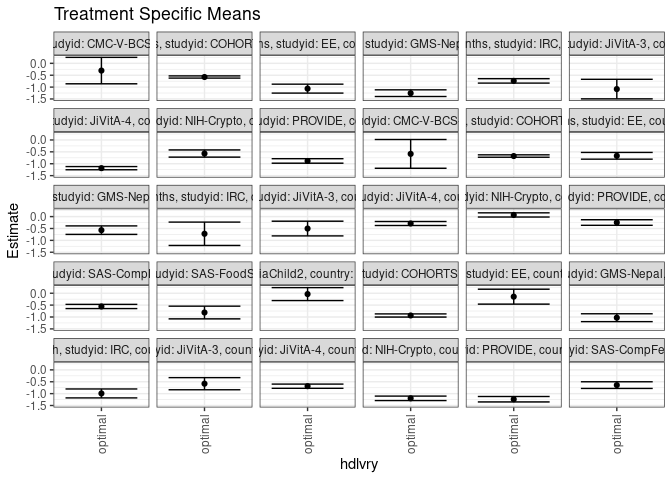

## Results Table

### Parameter: TSM

| agecat | studyid | country | intervention_level | baseline_level | estimate | ci_lower | ci_upper |
| --- | --- | --- | --- | --- | --- | --- | --- |
| Birth | COHORTS | INDIA | optimal | observed | -0.9361804 | -1.0031492 | -0.8692115 |
| Birth | EE | PAKISTAN | optimal | observed | -0.1446782 | -0.4586229 | 0.1692666 |
| Birth | GMS-Nepal | NEPAL | optimal | observed | -1.0296852 | -1.1945621 | -0.8648082 |
| Birth | IRC | INDIA | optimal | observed | -0.9919875 | -1.1805922 | -0.8033828 |
| Birth | JiVitA-3 | BANGLADESH | optimal | observed | -0.5817397 | -0.8371993 | -0.3262800 |
| Birth | JiVitA-4 | BANGLADESH | optimal | observed | -0.6874331 | -0.7754140 | -0.5994523 |
| Birth | NIH-Crypto | BANGLADESH | optimal | observed | -1.1979244 | -1.2920700 | -1.1037788 |
| Birth | PROVIDE | BANGLADESH | optimal | observed | -1.2355457 | -1.3494898 | -1.1216017 |
| Birth | SAS-CompFeed | INDIA | optimal | observed | -0.6413660 | -0.7823629 | -0.5003691 |
| 6 months | CMC-V-BCS-2002 | INDIA | optimal | observed | -0.5855050 | -1.1909653 | 0.0199554 |
| 6 months | COHORTS | INDIA | optimal | observed | -0.6767343 | -0.7274172 | -0.6260515 |
| 6 months | EE | PAKISTAN | optimal | observed | -0.6669836 | -0.8088420 | -0.5251253 |
| 6 months | GMS-Nepal | NEPAL | optimal | observed | -0.5705648 | -0.7493891 | -0.3917405 |
| 6 months | IRC | INDIA | optimal | observed | -0.7231593 | -1.2152238 | -0.2310948 |
| 6 months | JiVitA-3 | BANGLADESH | optimal | observed | -0.5025282 | -0.8114624 | -0.1935940 |
| 6 months | JiVitA-4 | BANGLADESH | optimal | observed | -0.2903334 | -0.3747751 | -0.2058917 |
| 6 months | NIH-Crypto | BANGLADESH | optimal | observed | 0.0696029 | -0.0190463 | 0.1582521 |
| 6 months | PROVIDE | BANGLADESH | optimal | observed | -0.2487060 | -0.3654168 | -0.1319951 |
| 6 months | SAS-CompFeed | INDIA | optimal | observed | -0.5574744 | -0.6457101 | -0.4692388 |
| 6 months | SAS-FoodSuppl | INDIA | optimal | observed | -0.8114743 | -1.0785248 | -0.5444239 |
| 6 months | TanzaniaChild2 | TANZANIA, UNITED REPUBLIC OF | optimal | observed | -0.0359194 | -0.3082187 | 0.2363799 |
| 24 months | CMC-V-BCS-2002 | INDIA | optimal | observed | -0.3051100 | -0.8609573 | 0.2507372 |
| 24 months | COHORTS | INDIA | optimal | observed | -0.5754524 | -0.6222585 | -0.5286464 |
| 24 months | EE | PAKISTAN | optimal | observed | -1.0646617 | -1.2521024 | -0.8772211 |
| 24 months | GMS-Nepal | NEPAL | optimal | observed | -1.2554446 | -1.3963974 | -1.1144919 |
| 24 months | IRC | INDIA | optimal | observed | -0.7381427 | -0.8309731 | -0.6453122 |
| 24 months | JiVitA-3 | BANGLADESH | optimal | observed | -1.0835172 | -1.4950409 | -0.6719935 |
| 24 months | JiVitA-4 | BANGLADESH | optimal | observed | -1.1861742 | -1.2538445 | -1.1185038 |
| 24 months | NIH-Crypto | BANGLADESH | optimal | observed | -0.5710595 | -0.7227169 | -0.4194022 |
| 24 months | PROVIDE | BANGLADESH | optimal | observed | -0.8830262 | -0.9773860 | -0.7886664 |

### Parameter: E(Y)

| agecat | studyid | country | intervention_level | baseline_level | estimate | ci_lower | ci_upper |
| --- | --- | --- | --- | --- | --- | --- | --- |
| Birth | COHORTS | INDIA | observed | observed | -0.9755867 | -1.0106993 | -0.9404741 |
| Birth | EE | PAKISTAN | observed | observed | -0.3410000 | -0.5302198 | -0.1517802 |
| Birth | GMS-Nepal | NEPAL | observed | observed | -1.1277349 | -1.2174865 | -1.0379833 |
| Birth | IRC | INDIA | observed | observed | -1.0105831 | -1.1973019 | -0.8238643 |
| Birth | JiVitA-3 | BANGLADESH | observed | observed | -0.8532192 | -0.9644938 | -0.7419446 |
| Birth | JiVitA-4 | BANGLADESH | observed | observed | -0.6907341 | -0.7437042 | -0.6377640 |
| Birth | NIH-Crypto | BANGLADESH | observed | observed | -1.2441513 | -1.3281130 | -1.1601897 |
| Birth | PROVIDE | BANGLADESH | observed | observed | -1.2984586 | -1.3752758 | -1.2216415 |
| Birth | SAS-CompFeed | INDIA | observed | observed | -0.6570846 | -0.8496671 | -0.4645022 |
| 6 months | CMC-V-BCS-2002 | INDIA | observed | observed | -0.5045068 | -0.6566169 | -0.3523968 |
| 6 months | COHORTS | INDIA | observed | observed | -0.7160077 | -0.7492815 | -0.6827338 |
| 6 months | EE | PAKISTAN | observed | observed | -0.7695800 | -0.8839306 | -0.6552294 |
| 6 months | GMS-Nepal | NEPAL | observed | observed | -0.5992551 | -0.6878945 | -0.5106156 |
| 6 months | IRC | INDIA | observed | observed | -0.5989297 | -0.7344491 | -0.4634104 |
| 6 months | JiVitA-3 | BANGLADESH | observed | observed | -0.6044910 | -0.7122040 | -0.4967781 |
| 6 months | JiVitA-4 | BANGLADESH | observed | observed | -0.3760651 | -0.4191017 | -0.3330285 |
| 6 months | NIH-Crypto | BANGLADESH | observed | observed | 0.0297622 | -0.0491685 | 0.1086930 |
| 6 months | PROVIDE | BANGLADESH | observed | observed | -0.1990907 | -0.2817968 | -0.1163845 |
| 6 months | SAS-CompFeed | INDIA | observed | observed | -0.6734421 | -0.8121314 | -0.5347528 |
| 6 months | SAS-FoodSuppl | INDIA | observed | observed | -1.0121579 | -1.1280429 | -0.8962729 |
| 6 months | TanzaniaChild2 | TANZANIA, UNITED REPUBLIC OF | observed | observed | 0.0688763 | 0.0147308 | 0.1230218 |
| 24 months | CMC-V-BCS-2002 | INDIA | observed | observed | -0.5436992 | -0.6434110 | -0.4439874 |
| 24 months | COHORTS | INDIA | observed | observed | -0.6520577 | -0.6860033 | -0.6181122 |
| 24 months | EE | PAKISTAN | observed | observed | -1.0103892 | -1.1580613 | -0.8627171 |
| 24 months | GMS-Nepal | NEPAL | observed | observed | -1.1238388 | -1.2161263 | -1.0315513 |
| 24 months | IRC | INDIA | observed | observed | -0.7458150 | -0.8368180 | -0.6548120 |
| 24 months | JiVitA-3 | BANGLADESH | observed | observed | -1.2989273 | -1.4377964 | -1.1600583 |
| 24 months | JiVitA-4 | BANGLADESH | observed | observed | -1.2421463 | -1.2763113 | -1.2079812 |
| 24 months | NIH-Crypto | BANGLADESH | observed | observed | -0.6103502 | -0.7050157 | -0.5156847 |
| 24 months | PROVIDE | BANGLADESH | observed | observed | -0.8928670 | -0.9755153 | -0.8102187 |

### Parameter: PAR

| agecat | studyid | country | intervention_level | baseline_level | estimate | ci_lower | ci_upper |
| --- | --- | --- | --- | --- | --- | --- | --- |
| Birth | COHORTS | INDIA | optimal | observed | -0.0394063 | -0.0956966 | 0.0168840 |
| Birth | EE | PAKISTAN | optimal | observed | -0.1963218 | -0.4278746 | 0.0352309 |
| Birth | GMS-Nepal | NEPAL | optimal | observed | -0.0980497 | -0.2300614 | 0.0339619 |
| Birth | IRC | INDIA | optimal | observed | -0.0185956 | -0.0516944 | 0.0145032 |
| Birth | JiVitA-3 | BANGLADESH | optimal | observed | -0.2714795 | -0.5357199 | -0.0072391 |
| Birth | JiVitA-4 | BANGLADESH | optimal | observed | -0.0033009 | -0.0752314 | 0.0686295 |
| Birth | NIH-Crypto | BANGLADESH | optimal | observed | -0.0462270 | -0.0947864 | 0.0023325 |
| Birth | PROVIDE | BANGLADESH | optimal | observed | -0.0629129 | -0.1496144 | 0.0237886 |
| Birth | SAS-CompFeed | INDIA | optimal | observed | -0.0157187 | -0.1059920 | 0.0745547 |
| 6 months | CMC-V-BCS-2002 | INDIA | optimal | observed | 0.0809981 | -0.5253243 | 0.6873206 |
| 6 months | COHORTS | INDIA | optimal | observed | -0.0392733 | -0.0784532 | -0.0000934 |
| 6 months | EE | PAKISTAN | optimal | observed | -0.1025964 | -0.2003830 | -0.0048097 |
| 6 months | GMS-Nepal | NEPAL | optimal | observed | -0.0286902 | -0.1859662 | 0.1285858 |
| 6 months | IRC | INDIA | optimal | observed | 0.1242296 | -0.3397958 | 0.5882549 |
| 6 months | JiVitA-3 | BANGLADESH | optimal | observed | -0.1019628 | -0.3817514 | 0.1778258 |
| 6 months | JiVitA-4 | BANGLADESH | optimal | observed | -0.0857317 | -0.1572458 | -0.0142175 |
| 6 months | NIH-Crypto | BANGLADESH | optimal | observed | -0.0398406 | -0.0845487 | 0.0048674 |
| 6 months | PROVIDE | BANGLADESH | optimal | observed | 0.0496153 | -0.0391194 | 0.1383500 |
| 6 months | SAS-CompFeed | INDIA | optimal | observed | -0.1159677 | -0.2577741 | 0.0258387 |
| 6 months | SAS-FoodSuppl | INDIA | optimal | observed | -0.2006835 | -0.4457296 | 0.0443625 |
| 6 months | TanzaniaChild2 | TANZANIA, UNITED REPUBLIC OF | optimal | observed | 0.1047957 | -0.1646476 | 0.3742389 |
| 24 months | CMC-V-BCS-2002 | INDIA | optimal | observed | -0.2385891 | -0.7901966 | 0.3130183 |
| 24 months | COHORTS | INDIA | optimal | observed | -0.0766053 | -0.1095054 | -0.0437053 |
| 24 months | EE | PAKISTAN | optimal | observed | 0.0542725 | -0.0702645 | 0.1788096 |
| 24 months | GMS-Nepal | NEPAL | optimal | observed | 0.1316058 | 0.0223979 | 0.2408137 |
| 24 months | IRC | INDIA | optimal | observed | -0.0076723 | -0.0176940 | 0.0023493 |
| 24 months | JiVitA-3 | BANGLADESH | optimal | observed | -0.2154101 | -0.5985964 | 0.1677762 |
| 24 months | JiVitA-4 | BANGLADESH | optimal | observed | -0.0559721 | -0.1128745 | 0.0009303 |
| 24 months | NIH-Crypto | BANGLADESH | optimal | observed | -0.0392906 | -0.1544256 | 0.0758443 |
| 24 months | PROVIDE | BANGLADESH | optimal | observed | -0.0098408 | -0.0568351 | 0.0371535 |